# Supply Chain Analytics - IA2 - SANYAM JAIN (sj33448)

## Assignment #2: ARIMA Laboratory

#### Due: Nov. 18

#### (40 points)

### Part I. Estimating Growth Potential and Capacity Utilization

Suppose you are working for a firm in the restaurant business looking into the possibility of starting operations in Australia. Your company has already narrowed its focus to five states: (i) Queensland, (ii) Victoria, (iii) New South Wales, (iv) Western Australia, and (v) the Australian Capital Territory. The decision of locations to start operations depend on two factors:

1. **Growth Potential:** More than the size of the market itself, the firm is interested in starting operations in locations with high growth rates. The reasoning behind this decision is that it is easier to gain a foothold in a market that is growing than in one that is stagnant.
2. **Demand Variability:** There are two dimensions to demand variability. First, the change in mean demand from month to month over the year, i.e., the seasonality; and second, the volatility of the demand within each season. This is important as high levels of seasonality and high levels of uncertainty lead to reduced expected expected levels of capacity utilization and lower cash flows from operation.

To aid your analysis, we include in the code box below an ETS analysis of the sales (turnover) of the aggregate restaurant industry in each state. Please base your answers to question (1) and (2) on the results obtained by the analysis below.

```r
library(fpp3)
```

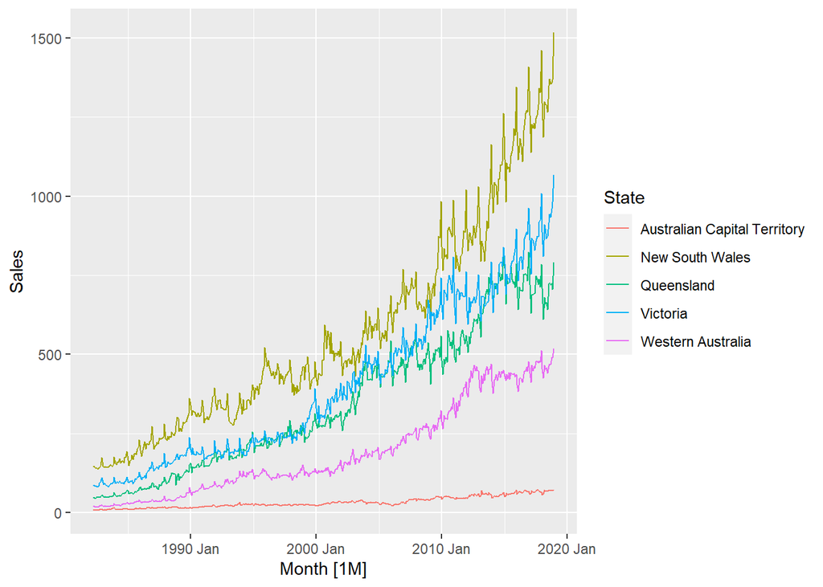

```r
R <- aus_retail %>%
  filter(Industry == "Cafes, restaurants and takeaway food services",
         State == "Australian Capital Territory"|
           State == "Queensland" |
           State == "Victoria" |
           State == "Western Australia" |
           State == "New South Wales" ) %>%
  mutate(Sales = Turnover) %>%
  select(State, Sales)

R %>% autoplot(.var = Sales)
```

```r
m <- R %>% model(me = ETS(Sales))

MC <- m %>% components()

MC %>% filter(State == "Australian Capital Territory") %>% filter(Month >= ym("2017 Dec"))
```

| State | .model | Month | Sales | level | slope | season | remainder |
| --- | --- | --- | --- | --- | --- | --- | --- |
| Australian Capital Territory | me | 2017 Dec | 63.6 | 59.98852 | 0.1524918 | 1.0973329 | -0.102180385 |
| Australian Capital Territory | me | 2018 Jan | 54.9 | 60.19809 | 0.1527651 | 0.9116048 | 0.001371245 |
| Australian Capital Territory | me | 2018 Feb | 59.8 | 63.51161 | 0.1678971 | 0.9211803 | 0.075664681 |
| Australian Capital Territory | me | 2018 Mar | 71.0 | 67.77859 | 0.1875214 | 1.0201030 | 0.092997687 |
| Australian Capital Territory | me | 2018 Apr | 67.3 | 68.81750 | 0.1915974 | 0.9725997 | 0.018097644 |
| Australian Capital Territory | me | 2018 May | 67.6 | 67.93466 | 0.1864536 | 1.0021199 | -0.022493755 |
| Australian Capital Territory | me | 2018 Jun | 67.2 | 68.99165 | 0.1906213 | 0.9685975 | 0.018462715 |
| Australian Capital Territory | me | 2018 Jul | 70.4 | 69.81827 | 0.1936661 | 1.0042652 | 0.013281383 |
| Australian Capital Territory | me | 2018 Aug | 69.2 | 68.81192 | 0.1879210 | 1.0134972 | -0.024762928 |
| Australian Capital Territory | me | 2018 Sep | 68.6 | 68.37128 | 0.1849118 | 1.0074628 | -0.013160843 |

[output cut: 3 more lines]

```r
MC %>% filter(State == "Queensland") %>% filter(Month >= ym("2017 Dec"))
```

| State | .model | Month | Sales | level | slope | season | remainder |
| --- | --- | --- | --- | --- | --- | --- | --- |
| Queensland | me | 2017 Dec | 785.5 | 708.8852 | -0.15164662 | 1.1098067 | -0.004644441 |
| Queensland | me | 2018 Jan | 708.6 | 694.1183 | -0.61114671 | 1.0317810 | -0.030992075 |
| Queensland | me | 2018 Feb | 611.5 | 682.1789 | -0.95774143 | 0.9039423 | -0.024570200 |
| Queensland | me | 2018 Mar | 680.1 | 690.2486 | -0.65355876 | 0.9788788 | 0.019869085 |
| Queensland | me | 2018 Apr | 658.3 | 685.6299 | -0.76635921 | 0.9629461 | -0.008668036 |
| Queensland | me | 2018 May | 665.5 | 680.7949 | -0.88024990 | 0.9804888 | -0.008959926 |
| Queensland | me | 2018 Jun | 641.9 | 673.0472 | -1.08049228 | 0.9586492 | -0.015215328 |
| Queensland | me | 2018 Jul | 721.8 | 698.0303 | -0.23489690 | 1.0150271 | 0.058230407 |
| Queensland | me | 2018 Aug | 725.8 | 709.7425 | 0.14766461 | 1.0140519 | 0.025715579 |
| Queensland | me | 2018 Sep | 719.5 | 715.4804 | 0.32168304 | 1.0016839 | 0.011838797 |

[output cut: 3 more lines]

```r
MC %>% filter(State == "New South Wales") %>% filter(Month >= ym("2017 Dec"))
```

| State | .model | Month | Sales | level | slope | season | remainder |
| --- | --- | --- | --- | --- | --- | --- | --- |
| New South Wales | me | 2017 Dec | 1461.4 | 1286.707 | 3.447773 | 1.1405078 | -0.018055811 |
| New South Wales | me | 2018 Jan | 1295.3 | 1271.632 | 3.340130 | 1.0229881 | -0.018575067 |
| New South Wales | me | 2018 Feb | 1187.6 | 1276.332 | 3.348030 | 0.9301880 | 0.001379556 |
| New South Wales | me | 2018 Mar | 1298.7 | 1300.134 | 3.466897 | 0.9943034 | 0.020679682 |
| New South Wales | me | 2018 Apr | 1288.2 | 1310.717 | 3.508255 | 0.9812559 | 0.007063263 |
| New South Wales | me | 2018 May | 1288.7 | 1307.336 | 3.468217 | 0.9872729 | -0.006782475 |
| New South Wales | me | 2018 Jun | 1265.2 | 1333.208 | 3.598412 | 0.9443294 | 0.022112588 |
| New South Wales | me | 2018 Jul | 1349.5 | 1363.411 | 3.753023 | 0.9841575 | 0.025748842 |
| New South Wales | me | 2018 Aug | 1370.7 | 1386.268 | 3.864044 | 0.9847847 | 0.018078846 |
| New South Wales | me | 2018 Sep | 1354.4 | 1375.871 | 3.781169 | 0.9874002 | -0.013272427 |

[output cut: 3 more lines]

```r
MC %>% filter(State == "Western Australia") %>% filter(Month >= ym("2017 Dec"))
```

| State | .model | Month | Sales | level | slope | season | remainder |
| --- | --- | --- | --- | --- | --- | --- | --- |
| Western Australia | me | 2017 Dec | 512.3 | 478.7444 | 1.222950 | 1.0684761 | 0.022312702 |
| Western Australia | me | 2018 Jan | 454.1 | 468.4103 | 1.171579 | 0.9720009 | -0.032999258 |
| Western Australia | me | 2018 Feb | 424.6 | 462.2062 | 1.138794 | 0.9201629 | -0.021525724 |
| Western Australia | me | 2018 Mar | 466.1 | 454.1121 | 1.097754 | 1.0285973 | -0.027308584 |
| Western Australia | me | 2018 Apr | 451.8 | 447.4121 | 1.063093 | 1.0116464 | -0.023476378 |
| Western Australia | me | 2018 May | 458.1 | 439.0646 | 1.021263 | 1.0457181 | -0.028756963 |
| Western Australia | me | 2018 Jun | 441.1 | 437.8485 | 1.011318 | 1.0079446 | -0.006967393 |
| Western Australia | me | 2018 Jul | 464.6 | 442.1348 | 1.025875 | 1.0500568 | 0.010226905 |
| Western Australia | me | 2018 Aug | 469.9 | 449.6919 | 1.054906 | 1.0435010 | 0.020197809 |
| Western Australia | me | 2018 Sep | 467.6 | 460.6579 | 1.098961 | 1.0130504 | 0.030134131 |

[output cut: 3 more lines]

```r
MC %>% filter(State == "Victoria") %>% filter(Month >= ym("2017 Dec"))
```

| State | .model | Month | Sales | level | slope | season | remainder |
| --- | --- | --- | --- | --- | --- | --- | --- |
| Victoria | me | 2017 Dec | 1008.1 | 894.5664 | 2.053611 | 1.1342554 | -0.018394971 |
| Victoria | me | 2018 Jan | 887.3 | 887.7802 | 1.765035 | 1.0047647 | -0.015041826 |
| Victoria | me | 2018 Feb | 810.6 | 882.2170 | 1.524492 | 0.9228862 | -0.012566461 |
| Victoria | me | 2018 Mar | 909.7 | 894.0352 | 1.778364 | 1.0112958 | 0.017917438 |
| Victoria | me | 2018 Apr | 898.6 | 907.5717 | 2.067576 | 0.9833028 | 0.020192104 |
| Victoria | me | 2018 May | 866.4 | 889.1724 | 1.455818 | 0.9864651 | -0.034425755 |
| Victoria | me | 2018 Jun | 873.1 | 912.6483 | 2.036779 | 0.9445034 | 0.037965180 |
| Victoria | me | 2018 Jul | 916.1 | 922.7419 | 2.217783 | 0.9881783 | 0.013580141 |
| Victoria | me | 2018 Aug | 943.8 | 938.7972 | 2.555521 | 0.9974659 | 0.023018933 |
| Victoria | me | 2018 Sep | 933.8 | 944.0908 | 2.577937 | 0.9875425 | 0.004549976 |

[output cut: 3 more lines]

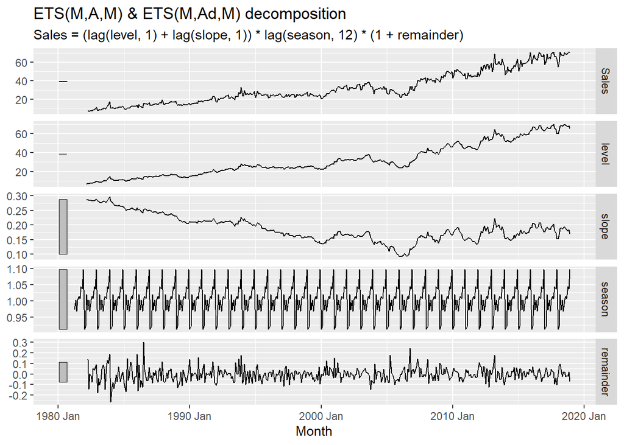

```r
MC %>% filter(State == "Australian Capital Territory") %>% autoplot()
```

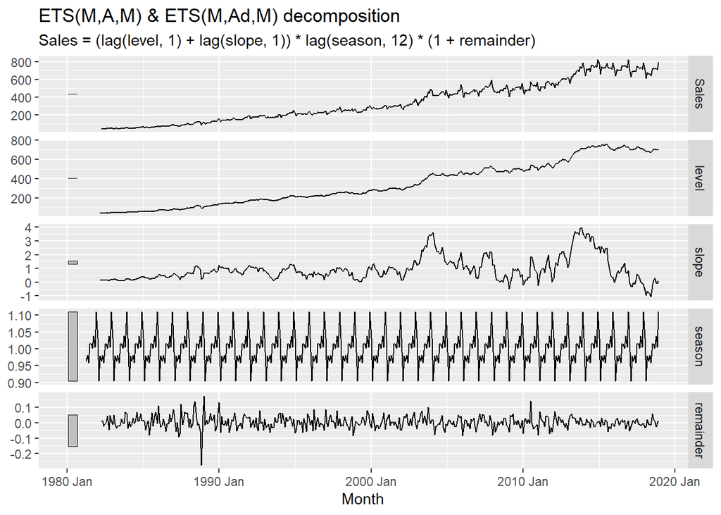

```r
MC %>% filter(State == "Queensland") %>% autoplot()
```

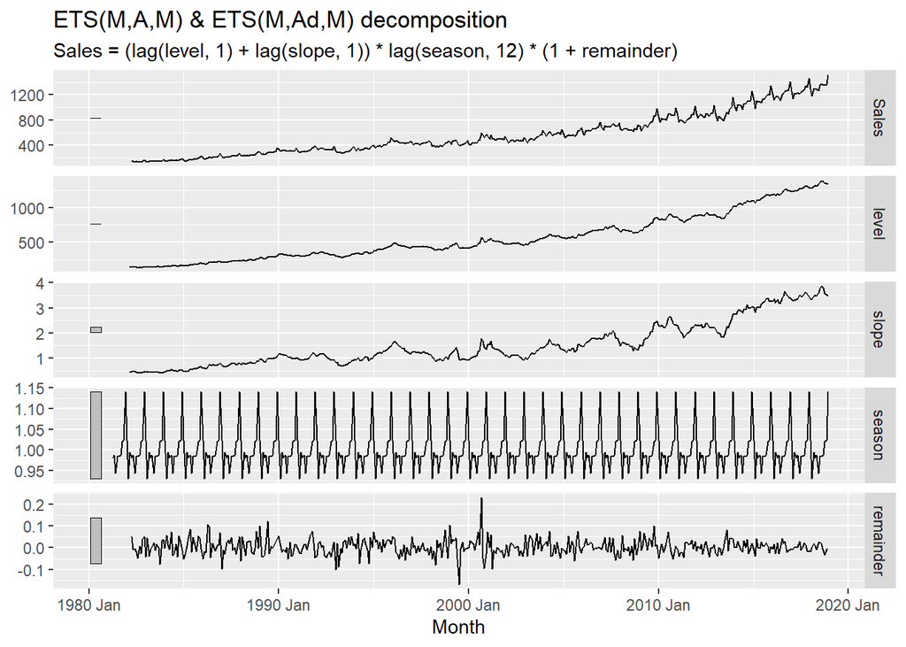

```r
MC %>% filter(State == "New South Wales") %>% autoplot()
```

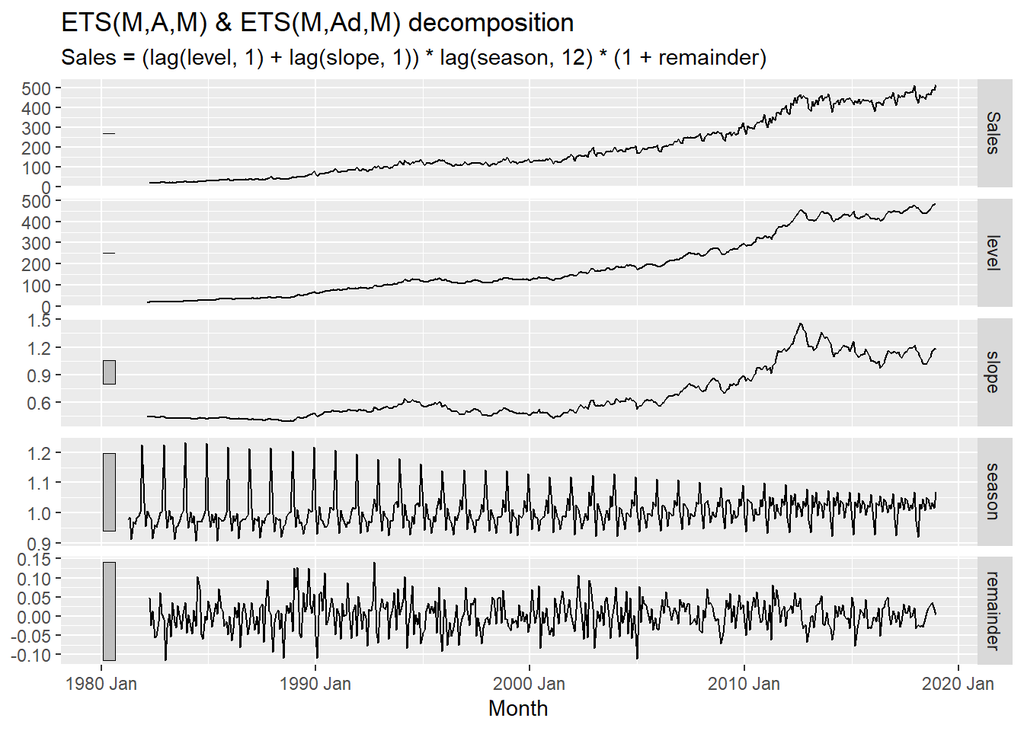

```r
MC %>% filter(State == "Western Australia") %>% autoplot()
```

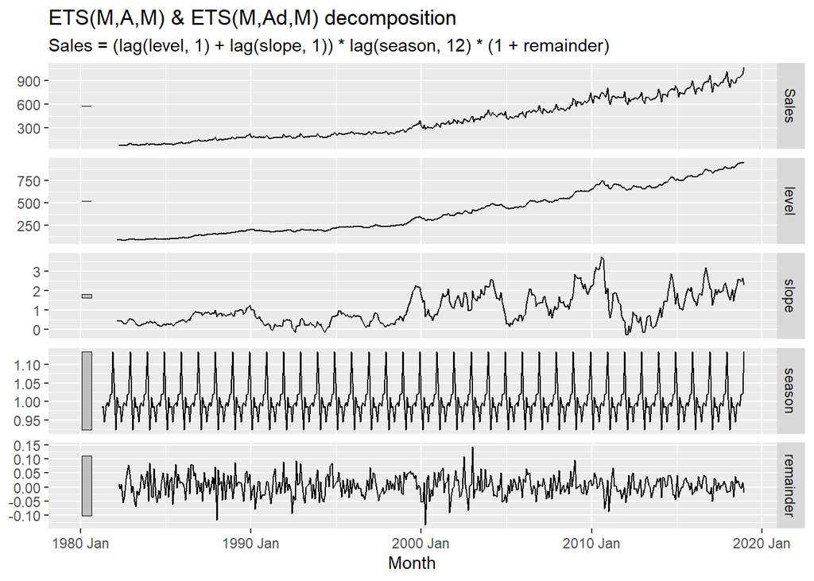

```r
MC %>% filter(State == "Victoria") %>% autoplot()
```

#### Q1: What is the type of growth estimated by the models above for each state?

Ans_1: The type of growth that is estimated by the models for each state is as follows:

1. *Australian Capital Territory* = **ETS(M,A,M)** = additive trend growth
2. *New South Wales* = **ETS(M,A,M)** = additive trend growth
3. *Queensland* = **ETS(M,Ad,M)** = additive damped trend growth
4. *Victoria* = **ETS(M,Ad,M)** = additive damped trend growth
5. *Western Australia* = **ETS(M,A,M)** = additive trend growth

#### Q2: What are the values of the growth parameters (for each state) at the end of analysis period?

Ans_2: Growth Parameter Values for each state are given below:

1. **Australian Capital Territory** : Level=65.414, Trend=0.168 & Seasonality=1.097
2. **New South Wales** : Level=1332.941, Trend=3.468 & Seasonality=1.140
3. **Queensland** : Level=709.307, Trend=0.117 & Seasonality=1.109
4. **Victoria** : Level=946.492, Trend=2.269460 & Seasonality=1.134
5. **Western Australia** has Level=483.580, Trend=1.185 & Seasonality=1.069

#### Q3: What is the growth rate (expressed as a percentage) of sales experienced by each state over the last twelve months? Calculate this as the percent change in the de-seasonalized level of demand estimated over the last twelve months?

Ans_3: Growth Rate (expressed as a percentage) experienced by each state over the last twelve months are:

```r
growth_values <- list(
  "Australian Capital Territory" = (65.414 - 59.988) * 100 / 59.988,
  "New South Wales" = (1332.941 - 1286.707) * 100 / 1286.707,
  "Queensland" = (709.307 - 708.885) * 100 / 708.885,
  "Victoria" = (946.492 - 894.566) * 100 / 894.566,
  "Western Australia" = (483.580 - 478.744) * 100 / 478.744
)

growth_values_only <- unlist(growth_values)

cat("Australian Capital Territory:", growth_values_only["Australian Capital Territory"],'\n')
```

```
## Australian Capital Territory: 9.045142
```

```r
cat("New South Wales:", growth_values_only["New South Wales"],'\n')
```

```
## New South Wales: 3.593203
```

```r
cat("Queensland:", growth_values_only["Queensland"],'\n')
```

```
## Queensland: 0.05953011
```

```r
cat("Victoria:", growth_values_only["Victoria"],'\n')
```

```
## Victoria: 5.804602
```

```r
cat("Western Australia:", growth_values_only["Western Australia"],'\n')
```

```
## Western Australia: 1.010143
```

#### Q4: One measure of operational risk is the effect of variability of mean demand from season to season on capacity utilization. A simple way to estimate this is to calculate for each of the five states $D_{MAX} = \max_m D_m$ where the index $m$ takes values corresponding to the last twelve months. That is, $D_{MAX}$ is the maximum mean level of demand fitted for the last twelve months. Then calculate the monthly metric of mean-forecast-based capacity utilization for each month as $$U_m = \frac{D_m}{D_{MAX}} \times 100,$$

#### then, using the monthly mean-based capacity utilization obtain the average mean-forecast-based utilization as $MU = mean(U_m)$ Report the utilization calculation for each of the five states. Summarize your analysis of sales growth potential and mean-variability with a table indicating the annual growth rate and annual average mean-base capacity utilization for each state. Management wants you to pick three of these five states to start operations base only on your analysis. explain your reasoning. Are there any states that are dominated by other states based only on the growth vs. utilization metrix? Explain.

Ans4:

```r
var_mean_dem <- MC %>% filter(Month > ym("2017 Dec"))
var_mean_dem <- var_mean_dem  %>% mutate(dem_mean = Sales/ (1+remainder))
var_mean_dem <- var_mean_dem %>% group_by(State) %>% mutate(dem_max = max(dem_mean))
var_mean_dem <- var_mean_dem  %>% mutate(mon_uti = (dem_mean/dem_max)*100)
var_mean_dem <- var_mean_dem  %>% mutate(mon_mean_cap_uti = mean(mon_uti))
var_mean_dem
```

| State | .model | Month | Sales | level | slope | season | remainder | dem_mean | dem_max | mon_uti | mon_mean_cap_uti |
| --- | --- | --- | --- | --- | --- | --- | --- | --- | --- | --- | --- |
| Australian Capital Territory | me | 2018 Jan | 54.9 | 60.19809 | 0.15276505 | 0.9116048 | 0.001371245 | 54.82482 | 75.5625 | 72.55559 | 88.67180 |
| Australian Capital Territory | me | 2018 Feb | 59.8 | 63.51161 | 0.16789713 | 0.9211803 | 0.075664681 | 55.59353 | 75.5625 | 73.57291 | 88.67180 |
| Australian Capital Territory | me | 2018 Mar | 71.0 | 67.77859 | 0.18752142 | 1.0201030 | 0.092997687 | 64.95897 | 75.5625 | 85.96720 | 88.67180 |
| Australian Capital Territory | me | 2018 Apr | 67.3 | 68.81750 | 0.19159744 | 0.9725997 | 0.018097644 | 66.10368 | 75.5625 | 87.48212 | 88.67180 |
| Australian Capital Territory | me | 2018 May | 67.6 | 67.93466 | 0.18645356 | 1.0021199 | -0.022493755 | 69.15557 | 75.5625 | 91.52101 | 88.67180 |
| Australian Capital Territory | me | 2018 Jun | 67.2 | 68.99165 | 0.19062129 | 0.9685975 | 0.018462715 | 65.98180 | 75.5625 | 87.32082 | 88.67180 |
| Australian Capital Territory | me | 2018 Jul | 70.4 | 69.81827 | 0.19366610 | 1.0042652 | 0.013281383 | 69.47725 | 75.5625 | 91.94672 | 88.67180 |
| Australian Capital Territory | me | 2018 Aug | 69.2 | 68.81192 | 0.18792102 | 1.0134972 | -0.024762928 | 70.95711 | 75.5625 | 93.90518 | 88.67180 |
| Australian Capital Territory | me | 2018 Sep | 68.6 | 68.37128 | 0.18491180 | 1.0074628 | -0.013160843 | 69.51487 | 75.5625 | 91.99652 | 88.67180 |
| Australian Capital Territory | me | 2018 Oct | 70.2 | 67.63594 | 0.18050613 | 1.0442259 | -0.019392912 | 71.58831 | 75.5625 | 94.74051 | 88.67180 |

[output cut: 50 more lines]

```r
var_mean_dem_summ <- data.frame(var_mean_dem) %>% dplyr::select(State, mon_uti ) %>% group_by(State) %>% summarise(mon_mean_cap_uti= mean(mon_uti))
var_mean_dem_summ<- var_mean_dem_summ %>%  mutate(growth=growth_values_only[State])
var_mean_dem_summ <- var_mean_dem_summ %>%  mutate(growth_Rank= rank(-growth*0.5))
var_mean_dem_summ <- var_mean_dem_summ %>%  mutate(mon_mean_cap_uti_rannk = rank(-mon_mean_cap_uti))
var_mean_dem_summ
```

| State | mon_mean_cap_uti | growth | growth_Rank | mon_mean_cap_uti_rannk |
| --- | --- | --- | --- | --- |
| Australian Capital Territory | 88.67180 | 9.04514236 | 1 | 3 |
| New South Wales | 86.75189 | 3.59320343 | 3 | 4 |
| Queensland | 89.18375 | 0.05953011 | 5 | 2 |
| Victoria | 84.36851 | 5.80460246 | 2 | 5 |
| Western Australia | 90.64272 | 1.01014321 | 4 | 1 |

Victoria and Queensland were not chosen; Victoria has low mean capacity utilization despite high growth potential, and Queensland has the lowest growth potential. The selections prioritize states excelling in either growth potential or mean capacity utilization.

### Part II. Estimating Downside Risk in Capacity Utilization

After looking at your analysis and considering a number of additional factors not included in your analysis, management decided to narrow their prospecting to New South Wales, Western Australia and Victoria, and are asking for a more detailed analysis of the capacity utilization risk. To estimate this risk, they are asking you to use the actual state-wide sales level as an index of what would be the company’s sales, and assume that the actual system capacity will be built as the 95% quantile of the forecasted demand. Management is tasking you to estimate the average capacity utilization and the downside capacity utilization risk for each state. The following questions guide you through this analysis:

#### Q5: Using the training and testing sets specified below, fit the best ETS and ARIMA models for the sales in each of these three states. Comment on the selection of a forecasting model for each state based on the validity, accuracy and information criteria for each model.

```r
# Break into Training and Testing sets.

S <- R %>%
  filter(State == "New South Wales" |
         State == "Western Australia" |
         State == "Victoria")

TR <- S %>%
  filter(Month >= yearmonth("2000 Jan"),
         Month <= yearmonth("2017 Dec"))
TE <- S %>%
  filter(Month >= yearmonth("2018 Jan"))
```

Ans_5: **ETS model:**

```r
ETS_best <- TR %>%  model(m.auto = ETS(Sales))
ETS_best %>% glance()
```

| State | .model | sigma2 | log_lik | AIC | AICc | BIC | MSE | AMSE | MAE |
| --- | --- | --- | --- | --- | --- | --- | --- | --- | --- |
| New South Wales | m.auto | 0.001276560 | -1279.652 | 2595.304 | 2598.776 | 2656.059 | 544.68618 | 906.5405 | 0.02433629 |
| Victoria | m.auto | 0.001260290 | -1218.608 | 2473.216 | 2476.688 | 2533.971 | 352.86546 | 547.2196 | 0.02590816 |
| Western Australia | m.auto | 0.001149717 | -1047.035 | 2130.070 | 2133.542 | 2190.825 | 80.51043 | 127.9762 | 0.02564549 |

```r
ETS_forecast <- ETS_best %>% forecast(h=12)
rbind(ETS_best %>% accuracy(), ETS_forecast %>% accuracy(data = TE))
```

| State | .model | .type | ME | RMSE | MAE | MPE | MAPE | MASE | RMSSE | ACF1 |
| --- | --- | --- | --- | --- | --- | --- | --- | --- | --- | --- |
| New South Wales | m.auto | Training | 2.8534661 | 23.338513 | 17.614931 | 0.2593568 | 2.408273 | 0.2641696 | 0.2848580 | 0.009867313 |
| Victoria | m.auto | Training | 2.4358623 | 18.784714 | 14.610114 | 0.3135465 | 2.581460 | 0.3491149 | 0.3727737 | 0.152017141 |
| Western Australia | m.auto | Training | 0.8613083 | 8.972761 | 6.983501 | 0.2652095 | 2.551286 | 0.2999420 | 0.2960339 | 0.004263488 |
| New South Wales | m.auto | Test | 19.1349108 | 30.111922 | 24.751110 | 1.4127596 | 1.843972 | NaN | NaN | 0.485163332 |
| Victoria | m.auto | Test | 2.8089587 | 28.500699 | 24.290835 | 0.1486781 | 2.614672 | NaN | NaN | 0.634403978 |
| Western Australia | m.auto | Test | -10.6695461 | 12.743475 | 10.669546 | -2.3121833 | 2.312183 | NaN | NaN | 0.656679443 |

**ARIMA model:**

```r
library('urca')
ARIMA_best<- TR %>%  model(ARIMA = ARIMA(Sales))
ARIMA_best %>% glance()
```

| State | .model | sigma2 | log_lik | AIC | AICc | BIC | ar_roots | ma_roots |
| --- | --- | --- | --- | --- | --- | --- | --- | --- |
| New South Wales | ARIMA | 710.59676 | -960.3375 | 1932.675 | 1933.101 | 1952.584 |  |  |
| Victoria | ARIMA | 424.74222 | -907.6822 | 1829.364 | 1829.936 | 1852.591 |  |  |
| Western Australia | ARIMA | 95.25629 | -755.3057 | 1522.611 | 1523.038 | 1542.520 |  |  |

```r
ARIMA_forecast <- ARIMA_best %>% forecast(h=12)
rbind(ARIMA_best %>% accuracy(), ARIMA_forecast %>% accuracy(data = TE))
```

| State | .model | .type | ME | RMSE | MAE | MPE | MAPE | MASE | RMSSE | ACF1 |
| --- | --- | --- | --- | --- | --- | --- | --- | --- | --- | --- |
| New South Wales | ARIMA | Training | -0.3315672 | 25.586523 | 19.64950 | -0.27608814 | 2.692457 | 0.2946818 | 0.3122961 | -0.0152927618 |
| Victoria | ARIMA | Training | 0.1836589 | 19.731879 | 15.22517 | -0.07485966 | 2.639147 | 0.3638120 | 0.3915697 | 0.0198619654 |
| Western Australia | ARIMA | Training | 0.0335593 | 9.367992 | 7.12444 | -0.15724227 | 2.571401 | 0.3059953 | 0.3090736 | -0.0008409102 |
| New South Wales | ARIMA | Test | 7.9432990 | 24.149191 | 18.96706 | 0.56856782 | 1.436014 | NaN | NaN | 0.5115018580 |
| Victoria | ARIMA | Test | 9.4405533 | 23.155710 | 19.02682 | 0.89926578 | 2.010926 | NaN | NaN | 0.5447355074 |
| Western Australia | ARIMA | Test | -28.9853192 | 30.492370 | 28.98532 | -6.27820334 | 6.278203 | NaN | NaN | 0.6845583516 |

#### Q6: Fit the actual models selected as the best ARIMA and ETS (see above) and re-fit these models using all the available data (i.e, the **S** data set), and then prepare a 12-month ahead forecast for each state. Report the forecast and the 80% and 90% confidence intervals for each state

Ans_6: Best models that will be considered for the three states are stated below:

- **Western Australia:** ARIMA(2,0,0)(0,1,2)[12] : Auto-Regression till the 2nd non-seasonal lag, 1st order seasonal difference and Moving Average at the 2nd seasonal level
- **Victoria**: ARIMA(1,0,1)(1,1,2)[12] : Auto-Regression till the 1st non-seasonal lag , Moving Average at the 1st non-seasonal level, Auto-Regression till the 1st seasonal lag ,1st order seasonal difference and Moving Average at the 2nd seasonal level
- **New South Wales**: ETS(M,Ad,M) :Multiplicative error, Additive Damped trend and Multiplicative seasonality

#### Western Australia

```r
West_Aust_best <- S %>% filter(State == "Western Australia") %>%  model(m.westaus = ARIMA(Sales ~ pdq(2,0,0) + PDQ(0,1,2)))
West_Aust_forecast <- West_Aust_best %>% forecast(h=12)
West_Aust_forecast
```

| State | .model | Month | Sales | .mean |
| --- | --- | --- | --- | --- |
| Western Australia | m.westaus | 2019 Jan |  | 470.7445 |
| Western Australia | m.westaus | 2019 Feb |  | 444.9695 |
| Western Australia | m.westaus | 2019 Mar |  | 486.7927 |
| Western Australia | m.westaus | 2019 Apr |  | 475.0529 |
| Western Australia | m.westaus | 2019 May |  | 484.6967 |
| Western Australia | m.westaus | 2019 Jun |  | 469.4620 |
| Western Australia | m.westaus | 2019 Jul |  | 492.6793 |
| Western Australia | m.westaus | 2019 Aug |  | 496.8751 |
| Western Australia | m.westaus | 2019 Sep |  | 492.4039 |
| Western Australia | m.westaus | 2019 Oct |  | 508.1541 |

[output cut: 2 more lines]

```r
West_Aust_forecast %>% hilo(level =c(80,90))%>%unpack_hilo("80%")%>%unpack_hilo("90%")%>% select(State, .model, Month, Sales, .mean, '80%_lower', '80%_upper', '90%_lower', '90%_upper')
```

| State | .model | Month | Sales | .mean | 80%_lower | 80%_upper | 90%_lower | 90%_upper |
| --- | --- | --- | --- | --- | --- | --- | --- | --- |
| Western Australia | m.westaus | 2019 Jan |  | 470.7445 | 461.1576 | 480.3315 | 458.4398 | 483.0492 |
| Western Australia | m.westaus | 2019 Feb |  | 444.9695 | 432.8759 | 457.0631 | 429.4475 | 460.4914 |
| Western Australia | m.westaus | 2019 Mar |  | 486.7927 | 472.5321 | 501.0533 | 468.4894 | 505.0959 |
| Western Australia | m.westaus | 2019 Apr |  | 475.0529 | 459.0492 | 491.0566 | 454.5124 | 495.5934 |
| Western Australia | m.westaus | 2019 May |  | 484.6967 | 467.1995 | 502.1939 | 462.2393 | 507.1542 |
| Western Australia | m.westaus | 2019 Jun |  | 469.4620 | 450.6644 | 488.2596 | 445.3356 | 493.5884 |
| Western Australia | m.westaus | 2019 Jul |  | 492.6793 | 472.7314 | 512.6271 | 467.0765 | 518.2820 |
| Western Australia | m.westaus | 2019 Aug |  | 496.8751 | 475.8990 | 517.8511 | 469.9526 | 523.7975 |
| Western Australia | m.westaus | 2019 Sep |  | 492.4039 | 470.5013 | 514.3065 | 464.2923 | 520.5155 |
| Western Australia | m.westaus | 2019 Oct |  | 508.1541 | 485.4114 | 530.8968 | 478.9641 | 537.3440 |

[output cut: 2 more lines]

#### Victoria

```r
Vict_best <- S %>% filter(State == "Victoria") %>%  model(m.vict = ARIMA(Sales ~ pdq(1,0,1) + PDQ(1,1,2)))
Vict_forecast<- Vict_best %>% forecast(h=12)
Vict_forecast
```

| State | .model | Month | Sales | .mean |
| --- | --- | --- | --- | --- |
| Victoria | m.vict | 2019 Jan |  | 956.0981 |
| Victoria | m.vict | 2019 Feb |  | 874.5759 |
| Victoria | m.vict | 2019 Mar |  | 961.9497 |
| Victoria | m.vict | 2019 Apr |  | 951.9347 |
| Victoria | m.vict | 2019 May |  | 935.7139 |
| Victoria | m.vict | 2019 Jun |  | 921.2219 |
| Victoria | m.vict | 2019 Jul |  | 960.2893 |
| Victoria | m.vict | 2019 Aug |  | 981.5563 |
| Victoria | m.vict | 2019 Sep |  | 976.0015 |
| Victoria | m.vict | 2019 Oct |  | 996.6447 |

[output cut: 2 more lines]

```r
Vict_forecast %>% hilo(level =c(80,90))%>%unpack_hilo("80%")%>%unpack_hilo("90%")%>%select(State, .model, Month, Sales, .mean, '80%_lower', '80%_upper', '90%_lower', '90%_upper')
```

| State | .model | Month | Sales | .mean | 80%_lower | 80%_upper | 90%_lower | 90%_upper |
| --- | --- | --- | --- | --- | --- | --- | --- | --- |
| Victoria | m.vict | 2019 Jan |  | 956.0981 | 935.8608 | 976.3354 | 930.1238 | 982.0724 |
| Victoria | m.vict | 2019 Feb |  | 874.5759 | 850.1392 | 899.0125 | 843.2118 | 905.9400 |
| Victoria | m.vict | 2019 Mar |  | 961.9497 | 934.1986 | 989.7008 | 926.3316 | 997.5678 |
| Victoria | m.vict | 2019 Apr |  | 951.9347 | 921.4453 | 982.4241 | 912.8020 | 991.0674 |
| Victoria | m.vict | 2019 May |  | 935.7139 | 902.9015 | 968.5262 | 893.5997 | 977.8280 |
| Victoria | m.vict | 2019 Jun |  | 921.2219 | 886.4048 | 956.0389 | 876.5347 | 965.9091 |
| Victoria | m.vict | 2019 Jul |  | 960.2893 | 923.7211 | 996.8574 | 913.3545 | 1007.2240 |
| Victoria | m.vict | 2019 Aug |  | 981.5563 | 943.4449 | 1019.6678 | 932.6408 | 1030.4719 |
| Victoria | m.vict | 2019 Sep |  | 976.0015 | 936.5205 | 1015.4825 | 925.3282 | 1026.6748 |
| Victoria | m.vict | 2019 Oct |  | 996.6447 | 955.9418 | 1037.3477 | 944.4031 | 1048.8864 |

[output cut: 2 more lines]

#### New South Wales

```r
NSW_best <- S %>% filter(State == "New South Wales") %>%  model(m.NSW = ETS(Sales ~ error("M") + trend("Ad") + season("M")))
NSW_forecast <- NSW_best %>% forecast(h=12)
NSW_forecast
```

| State | .model | Month | Sales | .mean |
| --- | --- | --- | --- | --- |
| New South Wales | m.NSW | 2019 Jan |  | 1363.988 |
| New South Wales | m.NSW | 2019 Feb |  | 1240.929 |
| New South Wales | m.NSW | 2019 Mar |  | 1327.944 |
| New South Wales | m.NSW | 2019 Apr |  | 1313.161 |
| New South Wales | m.NSW | 2019 May |  | 1325.017 |
| New South Wales | m.NSW | 2019 Jun |  | 1269.882 |
| New South Wales | m.NSW | 2019 Jul |  | 1328.868 |
| New South Wales | m.NSW | 2019 Aug |  | 1332.749 |
| New South Wales | m.NSW | 2019 Sep |  | 1339.461 |
| New South Wales | m.NSW | 2019 Oct |  | 1381.717 |

[output cut: 2 more lines]

```r
NSW_forecast %>% hilo(level =c(80,90))%>%unpack_hilo("80%")%>%unpack_hilo("90%")%>%
  select(State, .model, Month, Sales, .mean, '80%_lower', '80%_upper', '90%_lower', '90%_upper')
```

| State | .model | Month | Sales | .mean | 80%_lower | 80%_upper | 90%_lower | 90%_upper |
| --- | --- | --- | --- | --- | --- | --- | --- | --- |
| New South Wales | m.NSW | 2019 Jan |  | 1363.988 | 1296.874 | 1431.102 | 1277.848 | 1450.128 |
| New South Wales | m.NSW | 2019 Feb |  | 1240.929 | 1163.599 | 1318.258 | 1141.677 | 1340.180 |
| New South Wales | m.NSW | 2019 Mar |  | 1327.944 | 1230.559 | 1425.329 | 1202.952 | 1452.936 |
| New South Wales | m.NSW | 2019 Apr |  | 1313.161 | 1204.042 | 1422.281 | 1173.108 | 1453.215 |
| New South Wales | m.NSW | 2019 May |  | 1325.017 | 1203.114 | 1446.919 | 1168.557 | 1481.477 |
| New South Wales | m.NSW | 2019 Jun |  | 1269.882 | 1142.546 | 1397.219 | 1106.447 | 1433.317 |
| New South Wales | m.NSW | 2019 Jul |  | 1328.868 | 1185.268 | 1472.467 | 1144.560 | 1513.176 |
| New South Wales | m.NSW | 2019 Aug |  | 1332.749 | 1178.870 | 1486.628 | 1135.248 | 1530.250 |
| New South Wales | m.NSW | 2019 Sep |  | 1339.461 | 1175.326 | 1503.596 | 1128.796 | 1550.126 |
| New South Wales | m.NSW | 2019 Oct |  | 1381.717 | 1202.995 | 1560.440 | 1152.329 | 1611.105 |

[output cut: 2 more lines]

#### Q7: Using the forecasting models in Question 6, assume that your company will build capacity up to 95% of the maximum demand forecast for the following 12 months. That is, $CAP = \max_h D_{h,0.95}$, where $D_{h,0.95}$ is the maximum 95% quantile of the demand forecasts for the following 12 months. Then obtain the downside risk capacity utilization risk as $$DUR_h = \frac{D_{h,0.05}}{CAP} \times 100,$$ where $D_{h,0.05}$ is the demand corresponding to the 5% quantile of the sales forecast, and then, using the monthly downside capacity utilization $DUR_h$ obtain the average downside utilization as $MDU = mean(DUR_h)$ Report the utilization calculation for each of the three states.

Ans_7:

#### Western Australia

```r
#CAP
WA_95p <- West_Aust_forecast %>% mutate(Q95 = quantile(Sales, 0.95)) %>% mutate(CAP = max(Q95))
#DUR
WA_95p <- WA_95p %>% mutate(DUR = (quantile(Sales, 0.05)/CAP)*100)
#Mean DUR
WA_95p %>% mutate(data.frame(WA_95p) %>% dplyr::select(State, DUR ) %>% summarise(DUR_M= mean(DUR)))
```

| State | .model | Month | Sales | .mean | Q95 | CAP | DUR | DUR_M |
| --- | --- | --- | --- | --- | --- | --- | --- | --- |
| Western Australia | m.westaus | 2019 Jan |  | 470.7445 | 483.0492 | 559.5504 | 81.93002 | 82.95008 |
| Western Australia | m.westaus | 2019 Feb |  | 444.9695 | 460.4914 | 559.5504 | 76.74867 | 82.95008 |
| Western Australia | m.westaus | 2019 Mar |  | 486.7927 | 505.0959 | 559.5504 | 83.72604 | 82.95008 |
| Western Australia | m.westaus | 2019 Apr |  | 475.0529 | 495.5934 | 559.5504 | 81.22814 | 82.95008 |
| Western Australia | m.westaus | 2019 May |  | 484.6967 | 507.1542 | 559.5504 | 82.60905 | 82.95008 |
| Western Australia | m.westaus | 2019 Jun |  | 469.4620 | 493.5884 | 559.5504 | 79.58810 | 82.95008 |
| Western Australia | m.westaus | 2019 Jul |  | 492.6793 | 518.2820 | 559.5504 | 83.47352 | 82.95008 |
| Western Australia | m.westaus | 2019 Aug |  | 496.8751 | 523.7975 | 559.5504 | 83.98754 | 82.95008 |
| Western Australia | m.westaus | 2019 Sep |  | 492.4039 | 520.5155 | 559.5504 | 82.97595 | 82.95008 |
| Western Australia | m.westaus | 2019 Oct |  | 508.1541 | 537.3440 | 559.5504 | 85.59803 | 82.95008 |

[output cut: 2 more lines]

#### Victoria

```r
#CAP
V_95p <- Vict_forecast %>% mutate(Q95 = quantile(Sales, 0.95)) %>% mutate(CAP = max(Q95))
#DUR
V_95p <- V_95p %>% mutate(DUR = (quantile(Sales, 0.05)/CAP)*100)
#Mean DUR
V_95p %>% mutate(data.frame(V_95p) %>% dplyr::select(State, DUR ) %>% summarise(DUR_M= mean(DUR)))
```

| State | .model | Month | Sales | .mean | Q95 | CAP | DUR | DUR_M |
| --- | --- | --- | --- | --- | --- | --- | --- | --- |
| Victoria | m.vict | 2019 Jan |  | 956.0981 | 982.0724 | 1138.357 | 81.70754 | 81.10831 |
| Victoria | m.vict | 2019 Feb |  | 874.5759 | 905.9400 | 1138.357 | 74.07268 | 81.10831 |
| Victoria | m.vict | 2019 Mar |  | 961.9497 | 997.5678 | 1138.357 | 81.37441 | 81.10831 |
| Victoria | m.vict | 2019 Apr |  | 951.9347 | 991.0674 | 1138.357 | 80.18589 | 81.10831 |
| Victoria | m.vict | 2019 May |  | 935.7139 | 977.8280 | 1138.357 | 78.49905 | 81.10831 |
| Victoria | m.vict | 2019 Jun |  | 921.2219 | 965.9091 | 1138.357 | 76.99996 | 81.10831 |
| Victoria | m.vict | 2019 Jul |  | 960.2893 | 1007.2240 | 1138.357 | 80.23443 | 81.10831 |
| Victoria | m.vict | 2019 Aug |  | 981.5563 | 1030.4719 | 1138.357 | 81.92865 | 81.10831 |
| Victoria | m.vict | 2019 Sep |  | 976.0015 | 1026.6748 | 1138.357 | 81.28626 | 81.10831 |
| Victoria | m.vict | 2019 Oct |  | 996.6447 | 1048.8864 | 1138.357 | 82.96192 | 81.10831 |

[output cut: 2 more lines]

#### New South Wales

```r
#CAP
NSW_95p <- NSW_forecast %>% mutate(Quant_95 = quantile(Sales, 0.95)) %>% mutate(CAP = max(Quant_95))
#DUR
NSW_95p <- NSW_95p %>% mutate(DUR = (quantile(Sales, 0.05)/CAP)*100)
#Mean DUR
NSW_95p %>% mutate(data.frame(NSW_95p) %>% dplyr::select(State, DUR ) %>% summarise(DUR_M= mean(DUR)))
```

| State | .model | Month | Sales | .mean | Quant_95 | CAP | DUR | DUR_M |
| --- | --- | --- | --- | --- | --- | --- | --- | --- |
| New South Wales | m.NSW | 2019 Jan |  | 1363.988 | 1450.128 | 1822.508 | 70.11482 | 64.16464 |
| New South Wales | m.NSW | 2019 Feb |  | 1240.929 | 1340.180 | 1822.508 | 62.64319 | 64.16464 |
| New South Wales | m.NSW | 2019 Mar |  | 1327.944 | 1452.936 | 1822.508 | 66.00529 | 64.16464 |
| New South Wales | m.NSW | 2019 Apr |  | 1313.161 | 1453.215 | 1822.508 | 64.36781 | 64.16464 |
| New South Wales | m.NSW | 2019 May |  | 1325.017 | 1481.477 | 1822.508 | 64.11807 | 64.16464 |
| New South Wales | m.NSW | 2019 Jun |  | 1269.882 | 1433.317 | 1822.508 | 60.71016 | 64.16464 |
| New South Wales | m.NSW | 2019 Jul |  | 1328.868 | 1513.176 | 1822.508 | 62.80136 | 64.16464 |
| New South Wales | m.NSW | 2019 Aug |  | 1332.749 | 1530.250 | 1822.508 | 62.29042 | 64.16464 |
| New South Wales | m.NSW | 2019 Sep |  | 1339.461 | 1550.126 | 1822.508 | 61.93644 | 64.16464 |
| New South Wales | m.NSW | 2019 Oct |  | 1381.717 | 1611.105 | 1822.508 | 63.22767 | 64.16464 |

[output cut: 2 more lines]

Ans_8:

#### Western Australia

```r
#CAP
WA_10p <- West_Aust_forecast %>% mutate(Q70 = quantile(Sales, 0.70)) %>% mutate(CAP = max(Q70))
#DUR
WA_10p <-WA_10p %>% mutate(DUR = (quantile(Sales, 0.10)/CAP)*100)
#Mean DUR
WA_10p %>% mutate(data.frame(WA_10p) %>% dplyr::select(State, DUR ) %>% summarise(DUR_M= mean(DUR)))
```

| State | .model | Month | Sales | .mean | Q70 | CAP | DUR | DUR_M |
| --- | --- | --- | --- | --- | --- | --- | --- | --- |
| Western Australia | m.westaus | 2019 Jan |  | 470.7445 | 474.6674 | 538.3846 | 85.65579 | 87.18319 |
| Western Australia | m.westaus | 2019 Feb |  | 444.9695 | 449.9181 | 538.3846 | 80.40273 | 87.18319 |
| Western Australia | m.westaus | 2019 Mar |  | 486.7927 | 492.6280 | 538.3846 | 87.76851 | 87.18319 |
| Western Australia | m.westaus | 2019 Apr |  | 475.0529 | 481.6015 | 538.3846 | 85.26419 | 87.18319 |
| Western Australia | m.westaus | 2019 May |  | 484.6967 | 491.8564 | 538.3846 | 86.77803 | 87.18319 |
| Western Australia | m.westaus | 2019 Jun |  | 469.4620 | 477.1538 | 538.3846 | 83.70679 | 87.18319 |
| Western Australia | m.westaus | 2019 Jul |  | 492.6793 | 500.8418 | 538.3846 | 87.80553 | 87.18319 |
| Western Australia | m.westaus | 2019 Aug |  | 496.8751 | 505.4583 | 538.3846 | 88.39389 | 87.18319 |
| Western Australia | m.westaus | 2019 Sep |  | 492.4039 | 501.3663 | 538.3846 | 87.39131 | 87.18319 |
| Western Australia | m.westaus | 2019 Oct |  | 508.1541 | 517.4602 | 538.3846 | 90.16072 | 87.18319 |

[output cut: 2 more lines]

```r
#CAP
WA_50p <- West_Aust_forecast %>% mutate(Q70 = quantile(Sales, 0.70)) %>% mutate(CAP = max(Q70))
#DUR
WA_50p <-WA_50p %>% mutate(DUR = (quantile(Sales, 0.50)/CAP)*100)
#Mean DUR
WA_50p %>% mutate(data.frame(WA_50p) %>% dplyr::select(State, DUR ) %>% summarise(DUR_M= mean(DUR)))
```

| State | .model | Month | Sales | .mean | Q70 | CAP | DUR | DUR_M |
| --- | --- | --- | --- | --- | --- | --- | --- | --- |
| Western Australia | m.westaus | 2019 Jan |  | 470.7445 | 474.6674 | 538.3846 | 87.43648 | 90.61206 |
| Western Australia | m.westaus | 2019 Feb |  | 444.9695 | 449.9181 | 538.3846 | 82.64900 | 90.61206 |
| Western Australia | m.westaus | 2019 Mar |  | 486.7927 | 492.6280 | 538.3846 | 90.41728 | 90.61206 |
| Western Australia | m.westaus | 2019 Apr |  | 475.0529 | 481.6015 | 538.3846 | 88.23673 | 90.61206 |
| Western Australia | m.westaus | 2019 May |  | 484.6967 | 491.8564 | 538.3846 | 90.02798 | 90.61206 |
| Western Australia | m.westaus | 2019 Jun |  | 469.4620 | 477.1538 | 538.3846 | 87.19826 | 90.61206 |
| Western Australia | m.westaus | 2019 Jul |  | 492.6793 | 500.8418 | 538.3846 | 91.51066 | 90.61206 |
| Western Australia | m.westaus | 2019 Aug |  | 496.8751 | 505.4583 | 538.3846 | 92.29000 | 90.61206 |
| Western Australia | m.westaus | 2019 Sep |  | 492.4039 | 501.3663 | 538.3846 | 91.45951 | 90.61206 |
| Western Australia | m.westaus | 2019 Oct |  | 508.1541 | 517.4602 | 538.3846 | 94.38497 | 90.61206 |

[output cut: 2 more lines]

#### Victoria

```r
V_10p <- Vict_forecast %>% mutate(Q70 = quantile(Sales, 0.70)) %>% mutate(CAP = max(Q70))
#DUR
V_10p <- V_10p %>% mutate(DUR = (quantile(Sales, 0.10)/CAP)*100)
#Mean DUR
V_10p %>% mutate(data.frame(V_10p) %>% dplyr::select(State, DUR ) %>% summarise(DUR_M= mean(DUR)))
```

| State | .model | Month | Sales | .mean | Q70 | CAP | DUR | DUR_M |
| --- | --- | --- | --- | --- | --- | --- | --- | --- |
| Victoria | m.vict | 2019 Jan |  | 956.0981 | 964.3790 | 1100.953 | 85.00463 | 84.74369 |
| Victoria | m.vict | 2019 Feb |  | 874.5759 | 884.5752 | 1100.953 | 77.21851 | 84.74369 |
| Victoria | m.vict | 2019 Mar |  | 961.9497 | 973.3052 | 1100.953 | 84.85366 | 84.74369 |
| Victoria | m.vict | 2019 Apr |  | 951.9347 | 964.4107 | 1100.953 | 83.69527 | 84.74369 |
| Victoria | m.vict | 2019 May |  | 935.7139 | 949.1404 | 1100.953 | 82.01093 | 84.74369 |
| Victoria | m.vict | 2019 Jun |  | 921.2219 | 935.4687 | 1100.953 | 80.51253 | 84.74369 |
| Victoria | m.vict | 2019 Jul |  | 960.2893 | 975.2526 | 1100.953 | 83.90198 | 84.74369 |
| Victoria | m.vict | 2019 Aug |  | 981.5563 | 997.1512 | 1100.953 | 85.69350 | 84.74369 |
| Victoria | m.vict | 2019 Sep |  | 976.0015 | 992.1568 | 1100.953 | 85.06455 | 84.74369 |
| Victoria | m.vict | 2019 Oct |  | 996.6447 | 1013.3000 | 1100.953 | 86.82860 | 84.74369 |

[output cut: 2 more lines]

```r
V_50p <- Vict_forecast %>% mutate(Q70 = quantile(Sales, 0.70)) %>% mutate(CAP = max(Q70))
#DUR
V_50p <-V_50p %>% mutate(DUR = (quantile(Sales, 0.50)/CAP)*100)
#Mean DUR
V_50p %>% mutate(data.frame(V_50p) %>% dplyr::select(State, DUR ) %>% summarise(DUR_M= mean(DUR)))
```

| State | .model | Month | Sales | .mean | Q70 | CAP | DUR | DUR_M |
| --- | --- | --- | --- | --- | --- | --- | --- | --- |
| Victoria | m.vict | 2019 Jan |  | 956.0981 | 964.3790 | 1100.953 | 86.84280 | 87.84697 |
| Victoria | m.vict | 2019 Feb |  | 874.5759 | 884.5752 | 1100.953 | 79.43810 | 87.84697 |
| Victoria | m.vict | 2019 Mar |  | 961.9497 | 973.3052 | 1100.953 | 87.37430 | 87.84697 |
| Victoria | m.vict | 2019 Apr |  | 951.9347 | 964.4107 | 1100.953 | 86.46463 | 87.84697 |
| Victoria | m.vict | 2019 May |  | 935.7139 | 949.1404 | 1100.953 | 84.99129 | 87.84697 |
| Victoria | m.vict | 2019 Jun |  | 921.2219 | 935.4687 | 1100.953 | 83.67497 | 87.84697 |
| Victoria | m.vict | 2019 Jul |  | 960.2893 | 975.2526 | 1100.953 | 87.22348 | 87.84697 |
| Victoria | m.vict | 2019 Aug |  | 981.5563 | 997.1512 | 1100.953 | 89.15518 | 87.84697 |
| Victoria | m.vict | 2019 Sep |  | 976.0015 | 992.1568 | 1100.953 | 88.65063 | 87.84697 |
| Victoria | m.vict | 2019 Oct |  | 996.6447 | 1013.3000 | 1100.953 | 90.52566 | 87.84697 |

[output cut: 2 more lines]

#### New South Wales

```r
NSW_10p <- NSW_forecast %>% mutate(Q70 = quantile(Sales, 0.70)) %>% mutate(CAP = max(Q70))
#DUR
NSW_10p <-NSW_10p %>% mutate(DUR = (quantile(Sales, 0.10)/CAP)*100)
#Mean DUR
NSW_10p %>% mutate(data.frame(NSW_10p) %>% dplyr::select(State, DUR ) %>% summarise(DUR_M= mean(DUR)))
```

| State | .model | Month | Sales | .mean | Q70 | CAP | DUR | DUR_M |
| --- | --- | --- | --- | --- | --- | --- | --- | --- |
| New South Wales | m.NSW | 2019 Jan |  | 1363.988 | 1391.450 | 1630.768 | 79.52534 | 74.09598 |
| New South Wales | m.NSW | 2019 Feb |  | 1240.929 | 1272.571 | 1630.768 | 71.35280 | 74.09598 |
| New South Wales | m.NSW | 2019 Mar |  | 1327.944 | 1367.793 | 1630.768 | 75.45885 | 74.09598 |
| New South Wales | m.NSW | 2019 Apr |  | 1313.161 | 1357.812 | 1630.768 | 73.83282 | 74.09598 |
| New South Wales | m.NSW | 2019 May |  | 1325.017 | 1374.898 | 1630.768 | 73.77593 | 74.09598 |
| New South Wales | m.NSW | 2019 Jun |  | 1269.882 | 1321.987 | 1630.768 | 70.06180 | 74.09598 |
| New South Wales | m.NSW | 2019 Jul |  | 1328.868 | 1387.628 | 1630.768 | 72.68158 | 74.09598 |
| New South Wales | m.NSW | 2019 Aug |  | 1332.749 | 1395.715 | 1630.768 | 72.28926 | 74.09598 |
| New South Wales | m.NSW | 2019 Sep |  | 1339.461 | 1406.624 | 1630.768 | 72.07194 | 74.09598 |
| New South Wales | m.NSW | 2019 Oct |  | 1381.717 | 1454.849 | 1630.768 | 73.76858 | 74.09598 |

[output cut: 2 more lines]

```r
NSW_50p <- NSW_forecast %>% mutate(Q70 = quantile(Sales, 0.70)) %>% mutate(CAP = max(Q70))
#DUR
NSW_50p <-NSW_50p %>% mutate(DUR = (quantile(Sales, 0.50)/CAP)*100)
#Mean DUR
NSW_50p %>% mutate(data.frame(NSW_50p) %>% dplyr::select(State, DUR ) %>% summarise(DUR_M= mean(DUR)))
```

| State | .model | Month | Sales | .mean | Q70 | CAP | DUR | DUR_M |
| --- | --- | --- | --- | --- | --- | --- | --- | --- |
| New South Wales | m.NSW | 2019 Jan |  | 1363.988 | 1391.450 | 1630.768 | 83.64082 | 82.51651 |
| New South Wales | m.NSW | 2019 Feb |  | 1240.929 | 1272.571 | 1630.768 | 76.09472 | 82.51651 |
| New South Wales | m.NSW | 2019 Mar |  | 1327.944 | 1367.793 | 1630.768 | 81.43056 | 82.51651 |
| New South Wales | m.NSW | 2019 Apr |  | 1313.161 | 1357.812 | 1630.768 | 80.52411 | 82.51651 |
| New South Wales | m.NSW | 2019 May |  | 1325.017 | 1374.898 | 1630.768 | 81.25108 | 82.51651 |
| New South Wales | m.NSW | 2019 Jun |  | 1269.882 | 1321.987 | 1630.768 | 77.87019 | 82.51651 |
| New South Wales | m.NSW | 2019 Jul |  | 1328.868 | 1387.628 | 1630.768 | 81.48722 | 82.51651 |
| New South Wales | m.NSW | 2019 Aug |  | 1332.749 | 1395.715 | 1630.768 | 81.72523 | 82.51651 |
| New South Wales | m.NSW | 2019 Sep |  | 1339.461 | 1406.624 | 1630.768 | 82.13683 | 82.51651 |
| New South Wales | m.NSW | 2019 Oct |  | 1381.717 | 1454.849 | 1630.768 | 84.72799 | 82.51651 |

[output cut: 2 more lines]

Capacity (CAP) and Downside Risk (DUR_M) Analysis:

**===At 95% Capacity Quantile and 5% Downside Risk:===**

**Western Australia** : Capacity = 559.55  
Downside Risk = 82.95

**Victoria** : Capacity = 1138.35  
Downside Risk = 81.10

**New South Wales** : Capacity = 1822.50  
Downside Risk = 64.16

**===At 70% Capacity Quantile and 10% Downside Risk:===**

**Western Australia** : Capacity = 538.38  
Downside Risk = 87.18

**Victoria** : Capacity = 1100.95  
Downside Risk = 84.74

**New South Wales** : Capacity = 1630.76  
Downside Risk = 74.09

**===At 70% Capacity Quantile and 50% Downside Risk:===**

**Western Australia** : Capacity = 538.38  
Downside Risk = 90.61

**Victoria** : Capacity = 1100.95  
Downside Risk = 87.84

**New South Wales** : Capacity = 1630.76  
Downside Risk = 82.51

Comparing with Question 4:

- **Western Australia**: 90.64
- **Victoria**: 84.36
- **New South Wales**: 86.75

The values from Question 4 differ from those at 70% capacity quantile and 50% downside risk. This discrepancy could be because, in this analysis, capacity is considered at 70%, whereas in Question 4, it is equated to mean demand.